# mvAC50 beta agonists example

Steffen Renner

May 17th 2019

### Introduction

This dataset was published together with the mvAC50 package in the paper *“Gene-signatures predict biologically relevant dose-response potencies in phenotypic assays”* (yet to be published) and contains gene expression changes measured for 21 beta agonists, and three control compounds at 8 concentrations in THP1 cells. For comparison, the data contains also univariate cAMP activity in THP1 cells, measuring the activitiy of the pathway upstream of the gene expression. The objective of the publication was to benchmark conceptually diverse gene signature EC50 methods in comparison to cAMP EC50s.

The two datasets in the mvAC package relevant for the beta agonists example are:

| name | description |
| --- | --- |
| thp1_gene_rscores | change in gene expression induced by beta agonists for two sets of 8-gene signatures |
| thp1_cAMP | cAMP dose response data for beta agonists |

All datasets were measured in THP1 cells. Gene expression was measured after 4h , cAMp was measured after 20 min.

### Prepare dataset

The gene expression dataset is stored in a long format with every measurement for each gene in a separate line. For the multivariate signature scores function a wide format is required as input.

The gene expression for the 16 genes was measured in two separate expreriments, each measuring 8 genes in one well. Therefore the summary scores were calculated separately for both experiments. As input we use the change in gene expression normalized to the housekeeper (TBP). Therefore TBP is excluded from the analysis, as it is set to zero by the normalization.

Load libraries.

```r
  library(mvAC50)
  library(tidyverse)
```

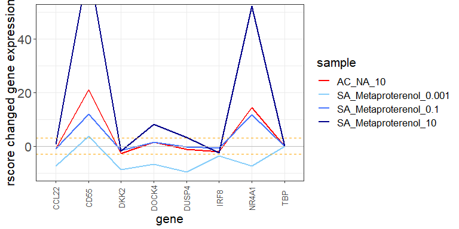

Figure 1. Example of raw data. Red is the active control gene signature of Isoproterenol, blue are the changes in gene expression at different concentrations of Metaproterenol.

```r
thp1_gene_rscores %>% filter(readout_set=="signature01" &  assay_plate=="plate01" &
  (well_type=="AC" | (cpd_name=="Metaproterenol" & conc_um %in% c(10,0.1, 0.001)) )) %>%
  mutate(id=paste(well_type, cpd_name, conc_um, sep="_")) %>%
  group_by(id, gene) %>% summarize(rscore_HKnorm=median(rscore_HKnorm)) %>%
  ggplot(aes(x=gene, y=rscore_HKnorm, group=id, colour=id)) +
  theme_bw()+
  geom_line(size=1)  +
  scale_color_manual(values=c("red","lightskyblue","royalblue1","darkblue")) +
  coord_cartesian(ylim=c(-10,50)) +
  geom_hline(yintercept=c(-3,3), linetype="dashed", colour="orange", size=.5) +
  geom_hline(yintercept=c(0), colour="grey", size=.5) +
  labs(x="gene", y="rscore changed gene expression", colour="sample") +
  theme(text = element_text(size = 16)) +
  theme(axis.title.x = element_text(size=16),axis.text.x  = element_text(angle=90, vjust=0.5, size=10)) +
  theme(axis.title.y = element_text(size=16),axis.text.y  = element_text(vjust=0.5, size=16))
```

Spread gene expression data to wide format to for the calculation of the multivariate signature scores by the `signature_scores` function.

```r
thp1_sig1 <- thp1_gene_rscores %>% filter(gene!="TBP" & readout_set=="signature01") %>%
  dplyr::select(-rscore)%>%
  spread(gene, rscore_HKnorm)

thp1_sig2 <- thp1_gene_rscores %>% filter(gene!="TBP" & readout_set=="signature02") %>%
  dplyr::select(-rscore)%>%
  spread(gene, rscore_HKnorm)
```

### Calculate gene signature summary scores

Prepare lists with names of metadata columns, data columns, etc, for the `signature_scores` function.

```r
# metadata columns in gene expression data.frames
all_metadata <- c("row","col","assay_plate","well_type","conc_um","inchi_key","smiles","biol_replicate","cpd_name","readout_set")

# subset of metadata columns to keep in multivariate scores output
keepvars <- c("cpd_name","conc_um","readout_set","well_type", "biol_replicate")

# gene expression columns in the data
readouts_s1 <- setdiff(colnames(thp1_sig1),all_metadata)
readouts_s2 <- setdiff(colnames(thp1_sig2),all_metadata)
```

List of signature summary scores to calculate. The list below containts all available scoring methods for the sake of a full benchmark.

```r
mv_methods <- c("maha_AC","maha_NC","euc_AC","euc_NC","cor_p_AC","cor_s_AC","dot_p_AC","cos_AC","vec_norm","scalar_projection_AC","cos_weight_AC","num_readouts_changed"  )
```

Calculate signature scores using the `signature_scores` function. From each signature the strongest responding individual genes are also kept for the calculation of single gene AC50s for comparison. These genes were manually selected and are specified in the `keep_readouts=c(...)` option. For the calculation, the column well_type specifies samples “SA”, and the two controls “AC” (active controls), and “NC” (neutral controls). The controls are used by some of the signature score methods. The grouping in the command below is done by plate to calculate signature scores for wells only based on controls of the same plate as the samples.

```r
thp1_sig1_scores <- thp1_sig1  %>% group_by(assay_plate) %>%
  do(signature_scores(., readouts=readouts_s1, keep_cols=keepvars, well_type = "well_type",
                      mv_methods=mv_methods, threshold=3, keep_readouts=c("CD55","DOCK4","NR4A1")))

thp1_sig2_scores <- thp1_sig2  %>% group_by(assay_plate) %>%
  do(signature_scores(., readouts=readouts_s2, keep_cols=keepvars, well_type = "well_type",
                      mv_methods=mv_methods, threshold=3, keep_readouts=c("PDE4B","SGK1","THBS1","TOB1","VEGFA")))

thp1_sig_scores <- rbind(thp1_sig1_scores, thp1_sig2_scores)
head(thp1_sig_scores)
```

```
## # A tibble: 6 x 12
## # Groups:   assay_plate [1]
##   assay_plate well_type conc_um biol_replicate cpd_name readout_set
##   <chr>       <chr>       <dbl>          <dbl> <chr>    <chr>
## 1 plate01     SA            100              1 CGP-207~ signature01
## 2 plate01     SA            100              1 Tulobut~ signature01
## 3 plate01     SA            100              1 Isoetha~ signature01
## 4 plate01     SA            100              1 Olodate~ signature01
## 5 plate01     SA            100              1 N-alpha~ signature01
## 6 plate01     SA            100              1 Vilante~ signature01
## # ... with 6 more variables: readout_name <chr>, readout_value <dbl>,
## #   readout_type <chr>, readout_class <chr>, readout_value_pctAC <dbl>,
## #   readout_value_pctACNC <dbl>
```

### Fit EC50s from univariate and multivariate readouts

Fit AC50s using the `fit_AC50` function. Only samples data is used for fitting (well_type == “SA”), as controls don’t have dose dependent data. Readouts for fitting were normalized to the active control by the `signature_scores` function already (100% = signal of the active control), which is the appropriate input column for the AC50 fitting.

```r
thp1_sig_ac50s <- thp1_sig_scores %>% filter(well_type=="SA") %>% group_by(cpd_name, biol_replicate, readout_name, readout_type, readout_class, readout_set) %>%
  do(fit_AC50(., conc_um="conc_um", readout_value_pctAC="readout_value_pctAC"))

# replace missing AC50s from constant fits etc with values 1 log unit above/below range of tested concentrations
thp1_sig_ac50s <- thp1_sig_ac50s %>% mutate(
  # if constant fit set AC50 to either 1 log unit above or below max tested concentration
  ac50=ifelse(fit_type=="constant" & amax > 50, 1e-06, ifelse(fit_type=="constant" & amax <= 50, 1000, ac50)),
  # if ainf < 50% activity, also set AC50 to one log unit above highest tested dose
  ac50=ifelse(fit_type %in% c("param","nonparam") & ainf < 50, 1000, ac50)
)
```

Process the raw univariate cAMP dose response data in the same way as above for a consistent comparison to gene and gene signature EC50s.

```r
thp1_cAMP_ac50s <- thp1_cAMP %>% filter(well_type=="SA") %>% group_by(cpd_name, biol_replicate, readout_name, readout_set) %>%
  do(fit_AC50(., conc_um="conc_um", readout_value_pctAC="readout_value_pctAC"))

# adjust ac50s like above
thp1_cAMP_ac50s <- thp1_cAMP_ac50s %>% mutate(
  # if constant fit set AC50 to either 1 log unit above or below max tested concentration
  ac50=ifelse(fit_type=="constant" & amax > 50, 1e-06, ifelse(fit_type=="constant" & amax <= 50, 1000, ac50)),
  # if ainf < 50% activity, also set AC50 to one log unit above highest tested dose
  ac50=ifelse(fit_type %in% c("param","nonparam") & ainf < 50, 1000, ac50)
) %>% rename(ac50_cAMP = ac50)

# join
thp1_sig_ac50s <- inner_join(thp1_sig_ac50s, thp1_cAMP_ac50s[,c("cpd_name","biol_replicate","ac50_cAMP")], by=c("cpd_name","biol_replicate"))
```

### Gene and gene signature EC50s compared to cAMP EC50s for seleted examples

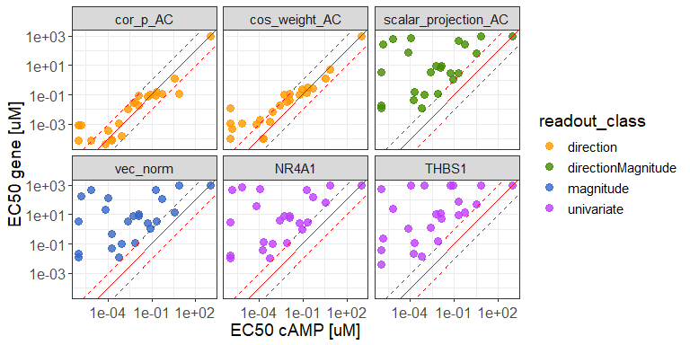

Figure 2. Comparison of gene and gene signature EC50s with cAMP EC50s for selected examples

```r
ggplot(thp1_sig_ac50s %>% filter( (readout_name == "THBS1" & biol_replicate == 2) | (readout_name %in% c("cor_p_AC","cos_weight_AC","scalar_projection_AC","vec_norm","NR4A1") & biol_replicate == 2 & readout_set == "signature01")), aes(x=ac50_cAMP, y=ac50, colour=readout_class)) +
  theme_bw()+
  geom_point(size=3, alpha=.8) +
  scale_x_log10() + scale_y_log10() +
  facet_wrap(~readout_name) +
  geom_abline(slope=1, color="red") +
  geom_abline(slope=1, intercept=1, linetype="dashed",color="red") +
  geom_abline(slope=1, intercept=-1, linetype="dashed",color="red") +
  scale_color_manual(values=c("#FF9900", "chartreuse4","#3366CC","darkorchid1","darkgrey"))+
  labs(x="EC50 cAMP [uM]", y="EC50 gene [uM]")+
  theme(text = element_text(size=14 )) +
  theme(axis.title.x = element_text(size=14),axis.text.x  = element_text(angle=0, vjust=0.5, size=12)) +
  theme(axis.title.y = element_text(size=14),axis.text.y  = element_text(vjust=0.5, size=12))
```

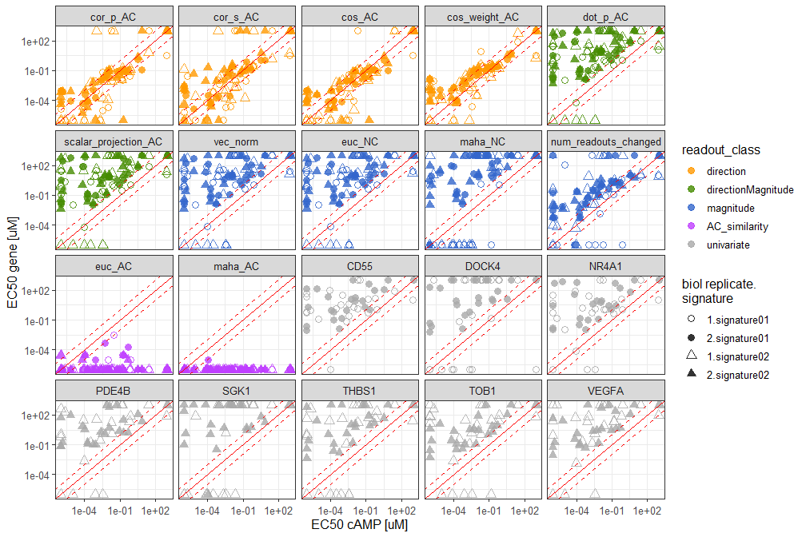

Figure 3. Comparison of all gene and gene signature EC50s for all gene signatures and biological replicateds compared with cAMP EC50s.

```r
ggplot(thp1_sig_ac50s, aes(x=ac50_cAMP, y=ac50, colour=readout_class, shape=interaction(biol_replicate,readout_set))) +
  theme_bw()+
  geom_point(size=3, alpha=.8) +
  scale_x_log10() + scale_y_log10() +
  facet_wrap(~readout_name) +
  geom_abline(slope=1, color="red") +
  geom_abline(slope=1, intercept=1, linetype="dashed",color="red") +
  geom_abline(slope=1, intercept=-1, linetype="dashed",color="red") +
  scale_color_manual(values=c("#FF9900", "chartreuse4","#3366CC","darkorchid1","darkgrey"))+
  scale_shape_manual(values=c(1,16,2,17))+
  labs(x="EC50 cAMP [uM]", y="EC50 gene [uM]", shape="biol replicate.\nsignature")+
  theme(text = element_text(size=12 )) +
  theme(axis.title.x = element_text(size=12),axis.text.x  = element_text(angle=0, vjust=0.5, size=10)) +
  theme(axis.title.y = element_text(size=12),axis.text.y  = element_text(vjust=0.5, size=10))
```

### Quantify correlation of gene and gene signature EC50s with cAMP EC50s

Calculate the correlations to cAMP EC50s.

```r
thp1_sig_ac50s.cor <- thp1_sig_ac50s %>% group_by(readout_name, biol_replicate, readout_set, readout_class) %>% summarize(
  num.datapoints=n(),
  rss.ac50=sum((log10(ac50)-log10(ac50_cAMP))^2,na.rm = TRUE),
  cor.pearson.ac50=cor(log10(ac50), log10(ac50_cAMP), use="pairwise.complete.obs"),
  cor.spearman.ac50=cor(log10(ac50), log10(ac50_cAMP), method="spearman", use="pairwise.complete.obs")
)
```

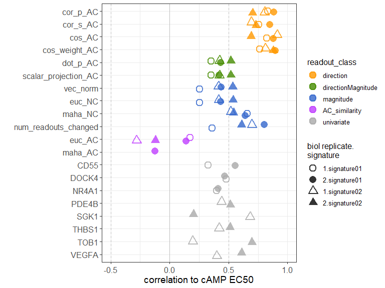

Figure 4. Correlation of cAMP EC50s with all gene and gene-signature EC50s

```r
ggplot(thp1_sig_ac50s.cor, aes(x=cor.pearson.ac50, y=readout_name, shape=interaction(biol_replicate,readout_set), colour=readout_class)) +
  theme_bw()+
  geom_vline(xintercept=c(-.5, .5), linetype="dashed", colour="grey", size=.5) +
  geom_vline(xintercept=c(0), colour="grey", size=.5) +
  geom_jitter(size=4, alpha=.8, stroke=1.5, height = .15) +
  theme(text = element_text(size=16 )) +
  coord_cartesian(xlim=c(-.5,1))+
  scale_y_discrete(name="", limits = rev(levels(thp1_sig_ac50s.cor$readout_name))) +
  scale_color_manual(values=c("#FF9900", "chartreuse4","#3366CC","darkorchid1","darkgrey"))+
  scale_shape_manual(values=c(1,16,2,17))+
  labs(x = "correlation to cAMP EC50", shape="biol replicate.\nsignature")+
  theme(text = element_text(size=12 )) +
  theme(axis.title.x = element_text(size=14),axis.text.x  = element_text(angle=0, vjust=0.5, size=12)) +
  theme(axis.title.y = element_text(size=14),axis.text.y  = element_text(vjust=0.5, size=12))
```